# 03 Introducción a la estimación de parámetros.

2024-01-17

## Tema 1.3 Distrubución T-Student

## Tema 1.3 Distrubución T-Student Historia

- La Dist. Normal fue derivada por Moivre in 1733 (de Moivre, 1738) para predecir juegos de azar.
- Su aplicación en la ciencia, en la astrología, se le atribuye a Gauss.
- William Sealy Gosset (1876), fue contratado por Guinness.
- Mejorar su proceso de elaboración cerveza a escala industrial.
- Utilizó experimentos con muestras pequeñas para sacar conclusiones.

## Tema 1.3 Distrubución T-Student Historia

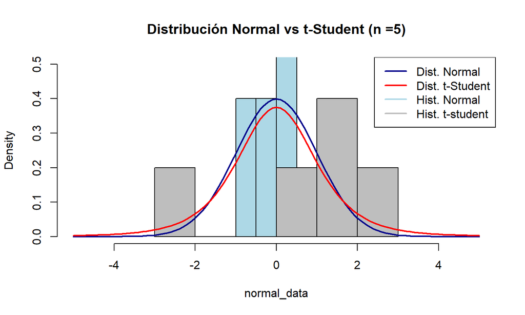

## Tema 1.3 Distrubución T-Student n=20

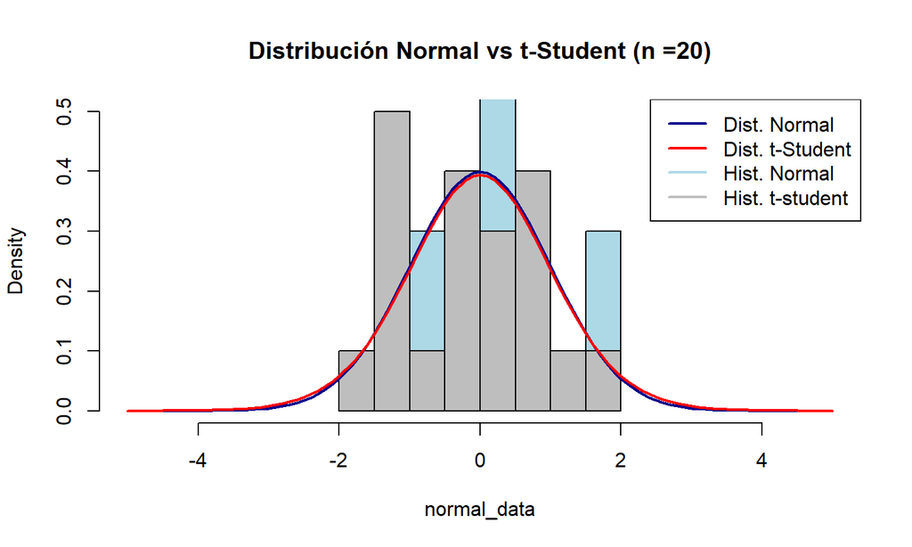

## Tema 1.3 Distrubución T-Student y Z-score

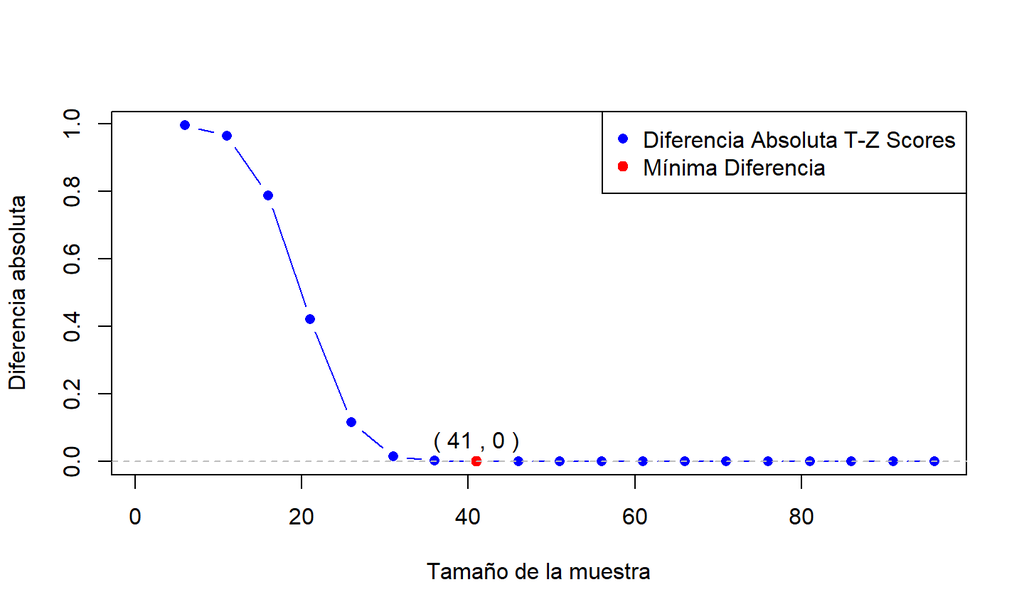

## Tema 1.3 Distrubución T-Student

¿Cuando se utiliza?

## Tema 1.3 Distrubución Z-score

- El z-score para localizar la media muestral alrededor de \(\mu\)

\[ Z = \frac{ \overline{x} - \mu}{\sigma/\sqrt{n}} \]

- El z-score para localizar puntos específicos alrededor de \(\mu\)

\[ Z = \frac{x_i - \mu}{\sigma/\sqrt{n}} \]

## Tema 1.3 Distrubución t-score

- El t-score para localizar la media muestral alrededor de \(\mu\)

\[ Z = \frac{ \overline{x} - \mu}{s/\sqrt{n}} \]

- El t-score para localizar puntos específicos alrededor de \(\mu\)

\[ Z = \frac{x_i - \mu}{s/\sqrt{n}} \]

## Revisión

## Revisión

```
## Versión: 24/01/2024
```

## Bibliografía

## Bibliografía

- Smith, G. (2015). *Essential statistics, regression, and econometrics.*
- Stock, J. H., & Watson, M. W. (2020). Introduction to econometrics. Pearson.
- Ross, S. M. (2014). A first course in probability.
- Lipschutz, S. (2000). Schaum’s outline of probability. McGraw Hill Professional.
- https://www.physoc.org/magazine-articles/the-strange-origins-of-the-students-t-test/